# A Quick Quarto Demo

A summary of just a few features

Author

John Helveston

# Quarto

This is a Quarto markdown document. Markdown is a simple formatting syntax for authoring HTML, PDF, and MS Word documents. For more details on using Quarto see the [Quarto website](https://quarto.org/).

## Useful tools

- Quick markdown reference guide: https://commonmark.org/help/
- Quick demo guide: https://markdown-it.github.io/.
- Online table converter: [http://www.tablesgenerator.com](http://www.tablesgenerator.com/markdown_tables)

# In-line code

In-line code allows you to insert R code directly into a sentence. For example, the sum of 3 and 4 is 7. Here the value of 7 was computed from `3 + 4` and inserted into the sentence.

You can also use variables. For example, the `bears` data frame has 166 rows.

# Code chunks

Code chunks are places to write longer bits of R code that will be compiled. For example, let’s say I wanted to show the first 6 rows of the `bears` data frame - I could write that in a chunk like this:

```r
head(bears)
```

```
#> # A tibble: 6 × 14
#>   name           age gender date  month  year wildOrCaptive location description
#>   <chr>        <dbl> <chr>  <chr> <dbl> <dbl> <chr>         <chr>    <chr>
#> 1 Mary Porter…     3 female 19/0…     5  1901 Wild          Job, We… The childr…
#> 2 Wilie Porte…     5 male   19/0…     5  1901 Wild          Job, We… The childr…
#> 3 Henry Porte…     7 male   19/0…     5  1901 Wild          Job, We… The childr…
#> 4 John Dicht      18 male   24/1…    11  1906 Wild          Elk Cou… Thinking t…
#> 5 Baby Laird       1 <NA>   05/1…    10  1908 Captive       Tucson,… After a be…
#> 6 Frank Welch     61 male   08/0…     9  1916 Wild          Yellows… Welch was …
#> # ℹ 5 more variables: bearType <chr>, hunter <dbl>, grizzly <dbl>, hiker <dbl>,
#> #   onlyOneKilled <dbl>
```

Now when compiled, the print out of `head(bears)` will show.

You can change how the chunk behave by changing some settings inside the `{r}` part of the chunk. For example, if I only want to show the result of the code (and not the code itself), I can set `echo: false`:

```
#> # A tibble: 6 × 14
#>   name           age gender date  month  year wildOrCaptive location description
#>   <chr>        <dbl> <chr>  <chr> <dbl> <dbl> <chr>         <chr>    <chr>
#> 1 Mary Porter…     3 female 19/0…     5  1901 Wild          Job, We… The childr…
#> 2 Wilie Porte…     5 male   19/0…     5  1901 Wild          Job, We… The childr…
#> 3 Henry Porte…     7 male   19/0…     5  1901 Wild          Job, We… The childr…
#> 4 John Dicht      18 male   24/1…    11  1906 Wild          Elk Cou… Thinking t…
#> 5 Baby Laird       1 <NA>   05/1…    10  1908 Captive       Tucson,… After a be…
#> 6 Frank Welch     61 male   08/0…     9  1916 Wild          Yellows… Welch was …
#> # ℹ 5 more variables: bearType <chr>, hunter <dbl>, grizzly <dbl>, hiker <dbl>,
#> #   onlyOneKilled <dbl>
```

If I only want to show the code but not actually run it, I can set `eval: false`:

```r
head(bears)
```

If I want to the code in the background but not show anything, I can set `include: false`:

# Plots

## Using ggplot

Here is an example of how to make a plot with ggplot2:

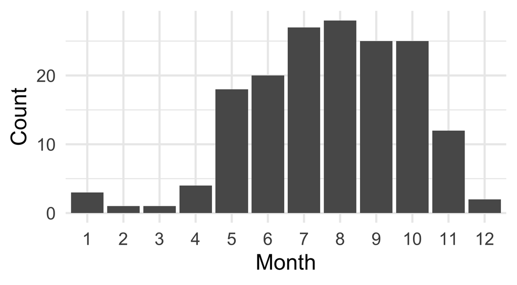

```r
bears %>%
  count(month) %>%
  ggplot() +
  geom_col(aes(x = as.factor(month), y = n)) +
  theme_minimal(base_size = 22) +
  labs(x = "Month", y = "Count")
```

## Inserting an image file

You can define the side using `out.width`, like this:

[figure not shown]